# TeamProject2

Dance Dance Revolution: Mario Prata Dias Alvarez, Sophie Kate Edelman, Meghan Sarah Hoffman, Elias Florentin John, Kritika Singh, Benjamin Victor Tward

2025-10-23

## Step 0: Why?

### Context, Objective, and Financial Model

Project Context: Realistic Spotify Metrics

To ground this analysis in real-world performance, we use approximate public and industry figures for a large streaming platform (Q3 2024 estimates):

Realistic Spotify Business Metrics

| Metric | Estimated Value | Rationale |
| --- | --- | --- |
| Monthly Active Users (MAU) | ~640 Million | Based on publicly reported figures. |
| Premium Subscribers | ~252 Million (39% of MAU) | Based on publicly reported subscription rates. |
| Revenue Q3 2024 | 4 billion (85% through Premium Subscribers) | Based on publicly reported figures. |
| Average Revenue Per User (ARPU) | ~$13.5 / month | ($4 billion * 0.85)/252 million |
| Estimated Monthly Churn Rate | ~2.0% | Industry estimate for major streaming services. |
| Customer Lifetime Value (CLV) | ~$675 | Calculated as ARPU / Churn Rate = $13.5 / 0.02. |

### Objective

Objective: To maximize user retention and daily active listening time, how can Spotify’s recommendation engine use a song’s audio features (danceability, energy, valence), track_genre, and other variables to build a predictive model that more accurately identifies high-engagement tracks (i.e., high future popularity) for its personalized playlists like ‘Discover Weekly’?

### Assumption & Financial Model

Assumption: A $10\%$ increase in the number of high-engagement songs a user hears in their ‘Discover Weekly’ playlist will lead to a very marginal $0.01\%$ decrease in their probability of churning (canceling their subscription) that month.

Further, there are 30 songs in the Discover weekly playlist. We assume that 20% of those are already hidden-gems.

### TP:

True positives have the following impact. Adding a hidden gem to the playlist results in an 80% chance of replacing a non–hidden gem and a 20% chance of replacing an existing hidden gem. Replacing a non–hidden gem increases the hidden-gem count from 6 to 7, a 16.67% lift. Because every 10% increase in hidden gems reduces churn by 0.01%, this lift translates to a 0.01667% churn reduction. The associated revenue impact is:

$$0.8 * \$ 252 \text{ million } * \$ 13.5
* 0.0001667$$

If the swap hits an existing hidden gem (20% probability), the hidden-gem count does not increase, creating an equivalent opportunity cost:

$$0.2 * \$ 252 \text{ million } * \$ 13.5
* 0.0001667$$

In total we have the following result:
$$\$ 252 \text{ million } * \$ 13.5 * 0.0001667 *
(0.8 - 0.2) = \$ 340,268.04$$

### FP:

Adding a non–hidden gem has the worst consequences. With an 80% chance, it simply replaces another non–hidden gem already in the playlist, generating no benefit. The only impact is the missed opportunity of adding a hidden gem, which we capture as opportunity cost:

$$0.8 * \$ 252 \text{ million } * \$ 13.5
* 0.0001667 * (0.8 - 0.2) = 0.8 * \$ 340,268.04$$

There is, however, a 20% chance that the swap replaces a hidden gem. This reduces the hidden-gem count from 7 to 6 — a 16.67% decline — which increases the churn rate by 0.01667%. In this case, we incur both the revenue loss from higher churn and the missed opportunity of improving churn:

$$0.2 * (\$ 252 \text{ million } * 13.5 *
(-0.0001667) - \$ 340,268.04 )$$

Combining both outcomes gives the total value of a false positive:

$$0.2 * (\$ 252 \text{ million } * 13.5 *
(-0.0001667) - \$ 340,268.04 ) - 0.8 * \$ 340,268.04 = - \$ 453,690.72$$

### FN:

For false negatives, the only impact is the opportunity cost of not adding a hidden gem:

$$- \$ 340,268.04$$

We translate this into the following Net Financial Impact model to guide the Level 2 Stacker. The model is designed to maximize Net Impact (Revenue - Loss). The $\$$ values reflect the estimated scaled impact on CLV and promotion costs per decision.

Net Financial Impact Model (Per Prediction)

| Outcome | Metric | Financial Value | Financial Rationale |
| --- | --- | --- | --- |
| True Positive (TP) | Correctly identifies a Hidden Gem (Target = ‘Yes’). | +$340,268.04 | Revenue: Estimated net monthly value derived from the 0.01667% reduction in churn for a high-value, retained customer. (Maximize) |
| False Positive (FP) | Predicts ‘Yes’, but actual is ‘No’. (Wasteful promotion) | -$453,690.72 | Cost: Significant loss from removing high-engaging content, and opportunity cost of promoting non-engaging content that accelerates churn. (Minimize - Critical Error) |
| False Negative (FN) | Predicts ‘No’, but actual is ‘Yes’. (Lost opportunity) | -$340,268.04 | Cost: Loss from missing a viable track and losing the opportunity for increased engagement and retention. (Minimize) |

### Net Impact Function

The objective is to maximize the Net Impact, calculated as:

$$\text{Net Impact} = \frac{(\text{TP} \times \$340,268.04) - (\text{FP}
\times \$453,690.72) - (\text{FN} \times \$340,268.04)}{\text{# Months
of Songs}}$$

## Stacked Model Architecture

The process uses a **6-model Level 1 (L1) Ensemble** feeding into a **Level 2 (L2) Stacker**.

[output not shown]

## Level 1 Step 1, 2, 3: Importing, Cleaning, Splitting, and Normalizing the Data

```r
source("modules/prep.R")
train = data.frame(X_train, popularity = y_train)
test = data.frame(X_test, popularity = y_test)
```

## Level 1 Step 4, 5, 6: Building, Predicting, and Analyzing the Models

### GLM

Work for this model was done in “modules/logistic.R”, however, since the file sizes were so large, the models, probabilities, and predictions were exported into separate files to be used below.

```r
glm_prob <- readRDS("probabilities/GLMProbs.RDS")
glm_pred <- readRDS("predictions/GLMPredictions.RDS")
```

```r
glm_confusion <- confusionMatrix(as.factor(glm_pred), as.factor(test$popularity), positive = "1")
glm_confusion
```

```
## Confusion Matrix and Statistics
##
##           Reference
## Prediction     0     1
##          0 62886  9936
##          1 14724 15054
##
##                Accuracy : 0.7596
##                  95% CI : (0.757, 0.7623)
##     No Information Rate : 0.7564
##     P-Value [Acc > NIR] : 0.008208
##
##                   Kappa : 0.3875
##
##  Mcnemar's Test P-Value : < 2.2e-16
##
##             Sensitivity : 0.6024
##             Specificity : 0.8103
##          Pos Pred Value : 0.5055
##          Neg Pred Value : 0.8636
##              Prevalence : 0.2436
##          Detection Rate : 0.1467
##    Detection Prevalence : 0.2902
##       Balanced Accuracy : 0.7063
##
##        'Positive' Class : 1
##
```

**What we changed to get the best results**

For the best results, we manipulated the threshold for the predictions to be popular or unpopular. Initially, we used a threshold of 0.5, but after optimizing for accuracy and sensitivity, we used a threshold of -0.6.

### ANN

Work for this model was done in “modules/ann.R”, however, since the file sizes were so large, the models, probabilities, and predictions were exported into separate files to be used below.

This is what the model looks like:

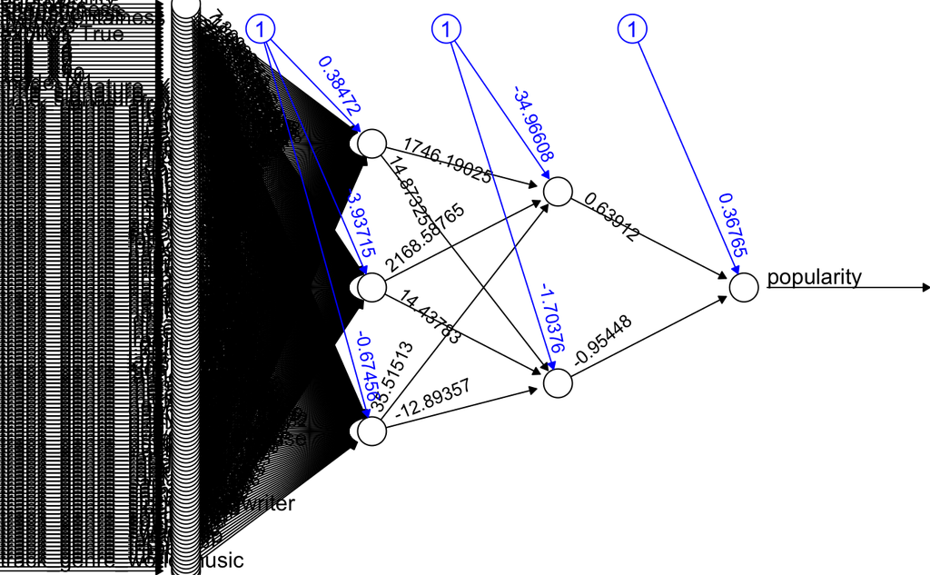

```r
#library(neuralnet)
ann_model <- readRDS("models/ANNModelM1.RDS")
#plot(ann_model)
```

Incredible.

```r
ann_prob <- readRDS("probabilities/ANNProbs.RDS")
ann_pred <- readRDS("predictions/ANNPredictions.RDS")
```

```r
ann_confusion <- confusionMatrix(as.factor(ann_pred), as.factor(test$popularity), positive = "1")
ann_confusion
```

```
## Confusion Matrix and Statistics
##
##           Reference
## Prediction     0     1
##          0 64408 11939
##          1 13202 13051
##
##                Accuracy : 0.755
##                  95% CI : (0.7523, 0.7576)
##     No Information Rate : 0.7564
##     P-Value [Acc > NIR] : 0.8647
##
##                   Kappa : 0.3462
##
##  Mcnemar's Test P-Value : 1.732e-15
##
##             Sensitivity : 0.5222
##             Specificity : 0.8299
##          Pos Pred Value : 0.4971
##          Neg Pred Value : 0.8436
##              Prevalence : 0.2436
##          Detection Rate : 0.1272
##    Detection Prevalence : 0.2559
##       Balanced Accuracy : 0.6761
##
##        'Positive' Class : 1
##
```

**What we changed to get the best results** For the best results, we manipulated the threshold for the predictions to be popular or unpopular. Initially, we used a threshold of 0.5, but after optimizing for accuracy and sensitivity, we used a threshold of 0.4.

### SVM

Work for this model was done in “modules/svm.R”, however, since the file sizes were so large, the models, probabilities, and predictions were exported into separate files to be used below.

```r
svm_prob <- readRDS("probabilities/SVMProbs.RDS")[, 1]
svm_pred <- readRDS("predictions/SVMPredictions.RDS")
```

```r
svm_confusion <- confusionMatrix(as.factor(svm_pred), as.factor(test$popularity), positive = "1")
svm_confusion
```

```
## Confusion Matrix and Statistics
##
##           Reference
## Prediction     0     1
##          0   289  1193
##          1 77321 23797
##
##                Accuracy : 0.2348
##                  95% CI : (0.2322, 0.2374)
##     No Information Rate : 0.7564
##     P-Value [Acc > NIR] : 1
##
##                   Kappa : -0.0217
##
##  Mcnemar's Test P-Value : <2e-16
##
##             Sensitivity : 0.952261
##             Specificity : 0.003724
##          Pos Pred Value : 0.235339
##          Neg Pred Value : 0.195007
##              Prevalence : 0.243567
##          Detection Rate : 0.231940
##    Detection Prevalence : 0.985556
##       Balanced Accuracy : 0.477992
##
##        'Positive' Class : 1
##
```

**What we changed to get the best results** For the best results, we manipulated the threshold for the predictions to be popular or unpopular. Initially, we used a threshold of 0.5, but after optimizing for accuracy and sensitivity, we used a threshold of 0.3.

### Random Forest

Work for this model was done in “modules/forest.R”, however, since the file sizes were so large, the models, probabilities, and predictions were exported into separate files to be used below.

```r
#library(randomForest)
forest_model <- readRDS("models/ForestModelM1.RDS")
#plot(forest_model)
```

And this is how important each variable is

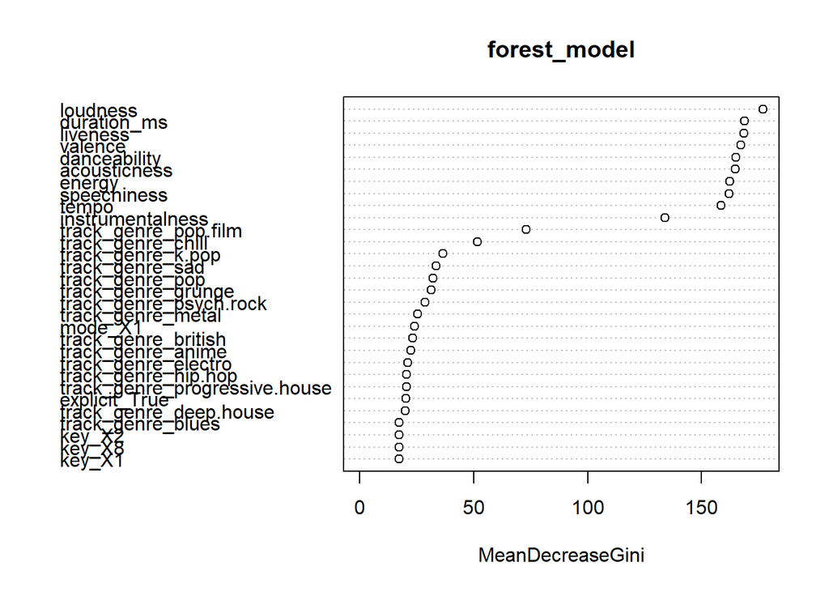

```r
randomForest::varImpPlot(forest_model)
```

```r
forest_prob <- readRDS("probabilities/ForestProbs.RDS")
forest_pred <- readRDS("predictions/ForestPredictions.RDS")
```

```r
forest_confusion <- confusionMatrix(as.factor(forest_pred), as.factor(test$popularity), positive = "1")
forest_confusion
```

```
## Confusion Matrix and Statistics
##
##           Reference
## Prediction     0     1
##          0 70170 12649
##          1  7440 12341
##
##                Accuracy : 0.8042
##                  95% CI : (0.8018, 0.8066)
##     No Information Rate : 0.7564
##     P-Value [Acc > NIR] : < 2.2e-16
##
##                   Kappa : 0.4282
##
##  Mcnemar's Test P-Value : < 2.2e-16
##
##             Sensitivity : 0.4938
##             Specificity : 0.9041
##          Pos Pred Value : 0.6239
##          Neg Pred Value : 0.8473
##              Prevalence : 0.2436
##          Detection Rate : 0.1203
##    Detection Prevalence : 0.1928
##       Balanced Accuracy : 0.6990
##
##        'Positive' Class : 1
##
```

**What we changed to get the best results** For the best results, we manipulated the threshold for the predictions to be popular or unpopular. Initially, we used a threshold of 0.3, but after optimizing for accuracy and sensitivity, we used a threshold of 0.35.

### KNN

Work for this model was done in “modules/knn.R”, however, since the file sizes were so large, the models, probabilities, and predictions were exported into separate files to be used below.

```r
knn_prob <- readRDS("probabilities/KNNProbs.RDS")
knn_pred <- readRDS("predictions/KNNPredictions.RDS")
```

```r
knn_confusion <- confusionMatrix(as.factor(knn_pred), as.factor(test$popularity), positive = "1")
knn_confusion
```

```
## Confusion Matrix and Statistics
##
##           Reference
## Prediction     0     1
##          0 55820 10833
##          1 21790 14157
##
##                Accuracy : 0.682
##                  95% CI : (0.6792, 0.6849)
##     No Information Rate : 0.7564
##     P-Value [Acc > NIR] : 1
##
##                   Kappa : 0.2488
##
##  Mcnemar's Test P-Value : <2e-16
##
##             Sensitivity : 0.5665
##             Specificity : 0.7192
##          Pos Pred Value : 0.3938
##          Neg Pred Value : 0.8375
##              Prevalence : 0.2436
##          Detection Rate : 0.1380
##    Detection Prevalence : 0.3504
##       Balanced Accuracy : 0.6429
##
##        'Positive' Class : 1
##
```

**What we changed to get the best results** For the best results, we manipulated the threshold for the predictions to be popular or unpopular. Initially, we used a threshold of 0.5, but after optimizing for accuracy and sensitivity, we used a threshold of 0.3.

### Decision Tree

Work for this model was done in “modules/knn.R”, however, since the file sizes were so large, the models, probabilities, and predictions were exported into separate files to be used below.

This is what this model looks like

[figure not shown]

```r
library(C50)
decision_model <- readRDS("models/DecisionModelM1.RDS")
plot(decision_model)
```

Incredible.

```r
decision_prob <- readRDS("probabilities/DecisionProbs.RDS")
decision_pred <- readRDS("predictions/DecisionPredictions.RDS")
```

```r
decision_confusion <- confusionMatrix(as.factor(decision_pred), as.factor(test$popularity), positive = "1")
decision_confusion
```

```
## Confusion Matrix and Statistics
##
##           Reference
## Prediction     0     1
##          0 70951 15650
##          1  6659  9340
##
##                Accuracy : 0.7826
##                  95% CI : (0.78, 0.7851)
##     No Information Rate : 0.7564
##     P-Value [Acc > NIR] : < 2.2e-16
##
##                   Kappa : 0.3279
##
##  Mcnemar's Test P-Value : < 2.2e-16
##
##             Sensitivity : 0.37375
##             Specificity : 0.91420
##          Pos Pred Value : 0.58379
##          Neg Pred Value : 0.81929
##              Prevalence : 0.24357
##          Detection Rate : 0.09103
##    Detection Prevalence : 0.15594
##       Balanced Accuracy : 0.64397
##
##        'Positive' Class : 1
##
```

Baseline for level 1:

```r
baseline_pred = rep(1, length(decision_pred))
baseline_confusion = confusionMatrix(as.factor(baseline_pred), as.factor(test$popularity), positive = "1")
```

```r
SONGS_PER_MONTH = 30
TP_PROFIT = 200
FP_COST =   500
FN_COST =   100

netimpact = function(conf, elias=TRUE) {
  t= conf$table
  tp = t[2,2]
  fp = t[2,1]
  fn = t[1,2]
  if (elias) {
    SONGS_PER_MONTH = 30
    TP_PROFIT = 340268
    FP_COST =   453690
    FN_COST =   340268
    n_months = sum(conf$table) / SONGS_PER_MONTH
    val = (TP_PROFIT*tp - FP_COST*fp - FN_COST*fn) / n_months
    return(val)
  } else {
    TP_PROFIT = 200
    FP_COST =   500
    FN_COST =   100
    val = (TP_PROFIT*tp - FP_COST*fp - FN_COST*fn)
    return(val)
  }
}

ni_improve = function(conf, bl) {
  ni_model = netimpact(conf)
  ni_base  = netimpact(bl)

  return((abs(ni_base) - abs(ni_model)) / abs(ni_base))
}

sumtable = function(conf_list, leveltwo = FALSE, bl1, bl2) {

  df = lapply(names(conf_list), function(nm) {
    conf = conf_list[[nm]]
    tibble(
      Model       = nm,
      Accuracy    = scales::percent(conf$overall["Accuracy"], accuracy = .01),
      Sensitivity = scales::percent(conf$byClass["Sensitivity"], accuracy = .01),
      Kappa       = signif(conf$overall[["Kappa"]], 2),
      `Net Impact` = scales::dollar(netimpact(conf)),
      improvement  = NA_character_
    )
  }) |> bind_rows()

  n = nrow(df)

  if (!leveltwo) {
    df$improvement =
      scales::percent(sapply(conf_list, ni_improve, bl = bl1), accuracy = .1)
  } else {
    df$improvement[1:(n-1)] =
      scales::percent(
        sapply(conf_list[1:(n-1)], ni_improve, bl = bl1),
        accuracy = .1
      )

    df$improvement[n-1] =
      scales::percent(
        ni_improve(conf_list[[n-1]], bl2),
        accuracy = .1
      )
    df$improvement[n] =
      scales::percent(
        ni_improve(conf_list[[n]], bl2),
        accuracy = .1
      )
  }
  kb = df |> rename(`% Improvement` = improvement) |>
    kableExtra::kbl(caption = "Model Performance Summary") |>
    kableExtra::kable_classic()

  if (leveltwo) {
    kb = kb |>
      kableExtra::group_rows("Level 1", 1, n - 2) |>
      kableExtra::group_rows("Level 2", n-1, n)
  }

  return(kb)
}
```

**What we changed to get the best results** For the best results, we manipulated the threshold for the predictions to be popular or unpopular. Initially, we used a threshold of 0.5, but after optimizing for accuracy and sensitivity, we used a threshold of 0.19.

### All of the Level 1 Models

Model Performance Summary

| Model | Accuracy | Sensitivity | Kappa | Net Impact | % Improvement |
| --- | --- | --- | --- | --- | --- |
| Baseline | 24.36% | 100.00% | 0.000 | -$7,809,235 | 0.0% |
| ANN | 75.50% | 52.22% | 0.350 | -$1,640,713 | 79.0% |
| KNN | 68.20% | 56.65% | 0.250 | -$2,559,899 | 67.2% |
| GLM | 75.96% | 60.24% | 0.390 | -$1,444,047 | 81.5% |
| SVM | 23.48% | 95.23% | -0.022 | -$8,008,288 | -2.5% |
| Forest | 80.42% | 49.38% | 0.430 | -$1,017,619 | 87.0% |
| Tree | 78.26% | 37.37% | 0.330 | -$1,511,173 | 80.6% |

### Combining the models

```r
combined_models <- data.frame(ann_pred, decision_pred, forest_pred, glm_pred, knn_pred, svm_pred, test$popularity)
```

## Part 2: Building a Second Level Decision Tree

Since we combined the models right above, there is no need to import of clean them.

### Step 3: Split the Data

```r
trainfrac2 <- 0.7
set.seed(12345)

trainrows <- sample(1:nrow(combined_models), trainfrac2*nrow(combined_models))

train2 <- combined_models[trainrows, ]
test2 <- combined_models[-trainrows, ]
```

### Step 4: Building the Model

```r
library(C50)
decision_2 <- C5.0(as.factor(test.popularity) ~., data = train2)
```

### Step 5: Predicting with the Model

```r
decision_p2 <- predict(decision_2, test2, type = "prob")
decision_p2 <- decision_p2[, 2]

decision_pred2 <- ifelse(decision_p2 >= .5, 1, 0)
```

### Step 6: Analyzing the Model

```r
decision2_confusion <- confusionMatrix(as.factor(decision_pred2), as.factor(test2$test.popularity), positive = "1")
decision2_confusion
```

```
## Confusion Matrix and Statistics
##
##           Reference
## Prediction     0     1
##          0 21081  3810
##          1  2193  3696
##
##                Accuracy : 0.805
##                  95% CI : (0.8005, 0.8094)
##     No Information Rate : 0.7561
##     P-Value [Acc > NIR] : < 2.2e-16
##
##                   Kappa : 0.4295
##
##  Mcnemar's Test P-Value : < 2.2e-16
##
##             Sensitivity : 0.4924
##             Specificity : 0.9058
##          Pos Pred Value : 0.6276
##          Neg Pred Value : 0.8469
##              Prevalence : 0.2439
##          Detection Rate : 0.1201
##    Detection Prevalence : 0.1913
##       Balanced Accuracy : 0.6991
##
##        'Positive' Class : 1
##
```

Baseline for level 2:

```r
baseline_pred2 = rep(1, length(decision_pred2))
baseline_confusion2 = confusionMatrix(as.factor(baseline_pred2), as.factor(test2$test.popularity), positive = "1")
```

## Step 7: Conclusion

Model Performance Summary

| Model | Accuracy | Sensitivity | Kappa | Net Impact | % Improvement |
| --- | --- | --- | --- | --- | --- |
| **Level 1** |  |  |  |  |  |
| Baseline | 24.36% | 100.00% | 0.000 | -$7,809,235 | 0.0% |
| ANN | 75.50% | 52.22% | 0.350 | -$1,640,713 | 79.0% |
| KNN | 68.20% | 56.65% | 0.250 | -$2,559,899 | 67.2% |
| GLM | 75.96% | 60.24% | 0.390 | -$1,444,047 | 81.5% |
| SVM | 23.48% | 95.23% | -0.022 | -$8,008,288 | -2.5% |
| Forest | 80.42% | 49.38% | 0.430 | -$1,017,619 | 87.0% |
| Tree | 78.26% | 37.37% | 0.330 | -$1,511,173 | 80.6% |
| **Level 2** |  |  |  |  |  |
| 2nd Level Baseline | 24.39% | 100.00% | 0.000 | -$7,802,270 | 0.0% |
| 2nd Level Tree | 80.50% | 49.24% | 0.430 | -$1,007,537 | 87.1% |